# Coursera Capstone Project: Milestone Report

A. Rodríguez

3/1/2021

## Data load.

```r
URL <- "https://d396qusza40orc.cloudfront.net/dsscapstone/dataset/Coursera-SwiftKey.zip"
download.file(URL, "./Capstone Dataset.zip")
unzip("./Capstone Dataset.zip", exdir = "./Capstone Project")
download.file("http://www.cs.cmu.edu/~biglou/resources/bad-words.txt","bad-words.txt")
```

The download of data into our directory is pretty straightforward, like in any other project done so far.

```r
Blog_file <- file("./Capstone Project/final/en_US/en_US.blogs.txt")
Twitter_file <- file("./Capstone Project/final/en_US/en_US.twitter.txt")
News_file <- file("./Capstone Project/final/en_US/en_US.news.txt")
Blog <- readLines(Blog_file)
Twitter <- readLines(Twitter_file)
```

```
## Warning in readLines(Twitter_file): line 1759032 appears to contain an embedded
## nul
```

```r
News <- readLines(News_file) ###Use default settings
```

```
## Warning in readLines(News_file): incomplete final line found on './Capstone
## Project/final/en_US/en_US.news.txt'
```

```r
Profanity <- readLines("bad-words.txt")
close(Blog_file)
close(Twitter_file)
close(News_file)
```

If you want to avoid warnings, you can set warn = FALSE, although shown warnings aren’t a big deal.

## General statistics.

### Word and line counts, data tables.

The table shown below contains the most basic features of the 3 datasets: words, lines, size, etc.

```r
library(stringi)
Names <- c("Blog", "Twitter", "News")
Length <- c(length(Blog), length(Twitter), length(News))
Chars <- c(sum(nchar(Blog)),sum(nchar(Twitter)),sum(nchar(News)))
Max_chars <- c(max(nchar(Blog)),max(nchar(Twitter)),max(nchar(News)))
Median_chars <- c(median(nchar(Blog)),median(nchar(Twitter)),median(nchar(News)))
Words <- c(sum(stri_count_words(Blog)),sum(stri_count_words(Twitter)),sum(stri_count_words(News)))
Size <- c(file.info("./Capstone Project/final/en_US/en_US.blogs.txt")$size /1024^2, file.info("./Capstone Project/final/en_US/en_US.twitter.txt")$size /1024^2, file.info("./Capstone Project/final/en_US/en_US.news.txt")$size /1024^2) ###Divide by 1024^2 to get MB
Data_table <- data.frame("Name" = Names, "Nº Lines" = Length, "Nº Characters" = Chars, "Max char in a line" = Max_chars, "Median chars per line" = Median_chars, "Nº words" = Words, "Size in MB" = Size)
Data_table
```

```
##      Name Nº.Lines Nº.Characters Max.char.in.a.line Median.chars.per.line
## 1    Blog   899288     208361438              40835                   157
## 2 Twitter  2360148     162384825                213                    64
## 3    News    77259      15683765               5760                   186
##   Nº.words Size.in.MB
## 1 38154238   200.4242
## 2 30218125   159.3641
## 3  2693898   196.2775
```

### Exploratory Data Analysis

As these datasets are very large, we’ll only take a sample from them (for example a 3% of each one) and join them in a single corpus with the same encoding (latin alphabet).

```r
set.seed(12345)
Blog_sample <- sample(Blog, length(Blog)*0.03)
Twitter_sample <- sample(Twitter, length(Twitter)*0.03)
News_sample <- sample(News, length(News)*0.03)
Total_sample <- c(Blog_sample, Twitter_sample, News_sample)
Corpus <- iconv(Total_sample, from = "UTF-8", to = "ASCII", sub = "")
```

Over this corpus, we’ll perform some cleaning. On the order written here, the steps taken to tidy the dataset is: convert to lowercase, remove punctuation marks, numbers, stopwords, “profanity” and extra whitespaces done by these removals.

```r
library(tm)
Corpus <- VCorpus(VectorSource(Corpus))
Corpus <- tm_map(Corpus, content_transformer(tolower))
Corpus <- tm_map(Corpus, removePunctuation)
Corpus <- tm_map(Corpus, removeNumbers)
Corpus <- tm_map(Corpus, removeWords, stopwords("english"))
Corpus <- tm_map(Corpus, removeWords, Profanity)
Corpus <- tm_map(Corpus, stripWhitespace)
Corpus <- tm_map(Corpus, PlainTextDocument)
```

After having cleaned the corpus, it’s time now to perform a few plots to ilustrate the most frequent n-grams (Unigrams, Bigrams, Trigrams and Quadgrams).

```r
library(RWeka)
library(tm)
unigram <- function(x) NGramTokenizer(x, Weka_control(min = 1, max = 1))
unigram_tdm <- TermDocumentMatrix(Corpus, control = list(tokenize = unigram))
unigram_freq <- findFreqTerms(unigram_tdm, lowfreq = 30)

bigram <- function(x) NGramTokenizer(x, Weka_control(min = 2, max = 2))
bigram_tdm <- TermDocumentMatrix(Corpus, control = list(tokenize = bigram))
bigram_freq <- findFreqTerms(bigram_tdm, lowfreq = 30)

trigram <- function(x) NGramTokenizer(x, Weka_control(min = 3, max = 3))
trigram_tdm <- TermDocumentMatrix(Corpus, control = list(tokenize = trigram))
trigram_freq <- findFreqTerms(trigram_tdm, lowfreq = 5)

quadgram <- function(x) NGramTokenizer(x, Weka_control(min = 4, max = 4))
quadgram_tdm <- TermDocumentMatrix(Corpus, control = list(tokenize = quadgram))
quadgram_freq <- findFreqTerms(quadgram_tdm, lowfreq = 5)
```

After having tokenized the corpus by these n-grams, we now features a barplot for each n-gram.

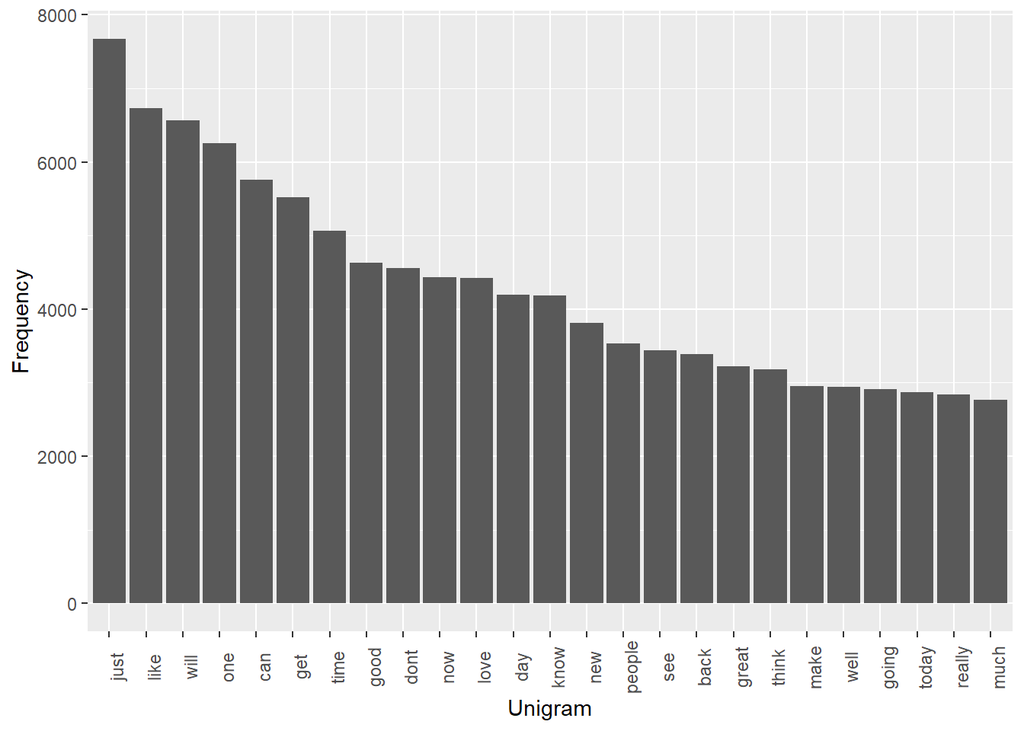

```r
library(ggplot2)
unigram_freq_sums <- rowSums(as.matrix(unigram_tdm[unigram_freq,]))
unigram_ord <- order(unigram_freq_sums, decreasing = T)
unigram_freq_sums <- data.frame(word=names(unigram_freq_sums[unigram_ord]), frequency=unigram_freq_sums[unigram_ord])

ggplot(unigram_freq_sums[1:25,], aes(factor(word, levels = unique(word)), frequency)) + geom_bar(stat = "identity") + theme(axis.text.x = element_text(angle = 90)) + xlab("Unigram") + ylab("Frequency")
```

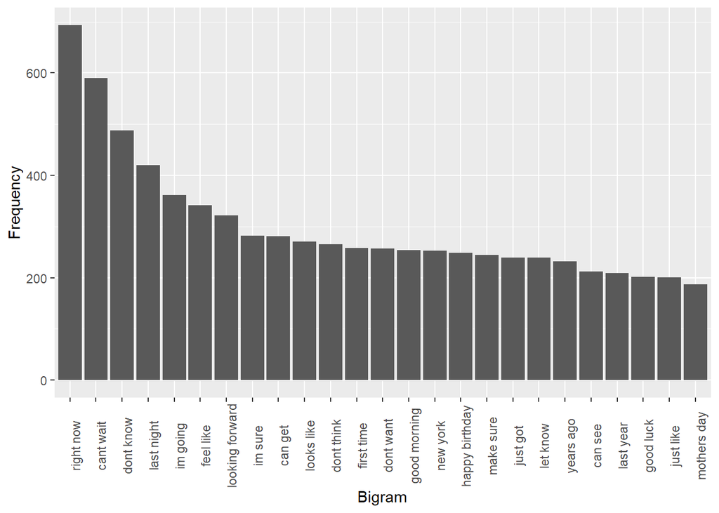

```r
library(ggplot2)
bigram_freq_sums <- rowSums(as.matrix(bigram_tdm[bigram_freq,]))
bigram_ord <- order(bigram_freq_sums, decreasing = T)
bigram_freq_sums <- data.frame(word=names(bigram_freq_sums[bigram_ord]), frequency=bigram_freq_sums[bigram_ord])

ggplot(bigram_freq_sums[1:25,], aes(factor(word, levels = unique(word)), frequency)) + geom_bar(stat = "identity") + theme(axis.text.x = element_text(angle = 90)) + xlab("Bigram") + ylab("Frequency")
```

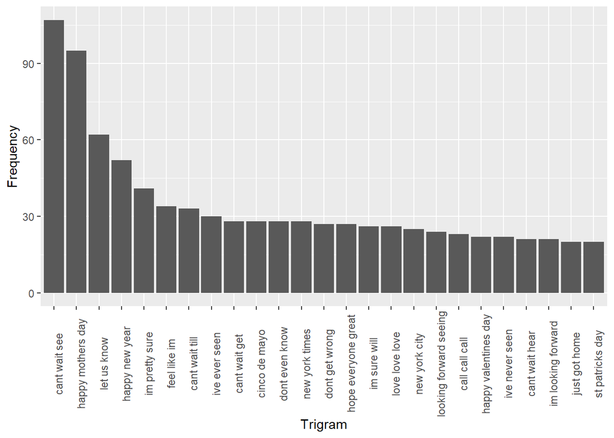

```r
library(ggplot2)
trigram_freq_sums <- rowSums(as.matrix(trigram_tdm[trigram_freq,]))
trigram_ord <- order(trigram_freq_sums, decreasing = T)
trigram_freq_sums <- data.frame(word=names(trigram_freq_sums[trigram_ord]), frequency=trigram_freq_sums[trigram_ord])

ggplot(trigram_freq_sums[1:25,], aes(factor(word, levels = unique(word)), frequency)) + geom_bar(stat = "identity") + theme(axis.text.x = element_text(angle = 90)) + xlab("Trigram") + ylab("Frequency")
```

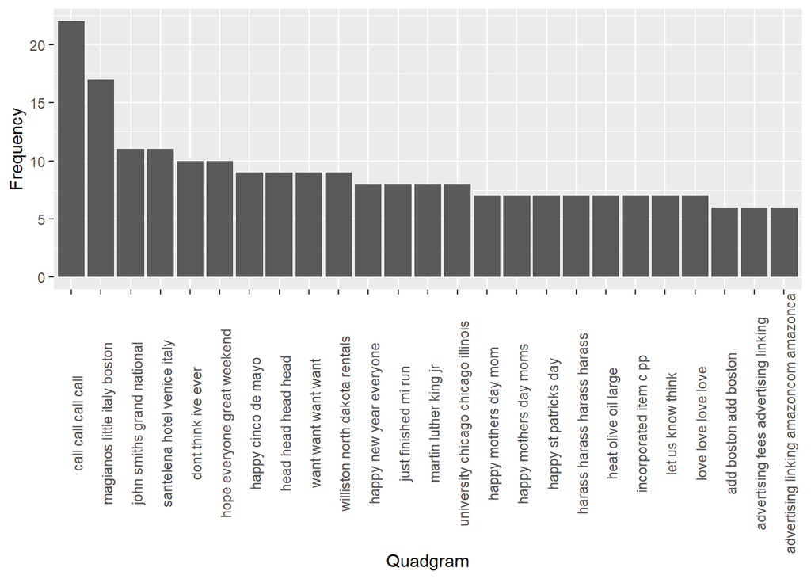

```r
quadgram_freq_sums <- rowSums(as.matrix(quadgram_tdm[quadgram_freq,]))
quadgram_ord <- order(quadgram_freq_sums, decreasing = T)
quadgram_freq_sums <- data.frame(word=names(quadgram_freq_sums[quadgram_ord]), frequency=quadgram_freq_sums[quadgram_ord])

ggplot(quadgram_freq_sums[1:25,], aes(factor(word, levels = unique(word)), frequency)) + geom_bar(stat = "identity") + theme(axis.text.x = element_text(angle = 90)) + xlab("Quadgram") + ylab("Frequency")
```

## Interesting findins

Using quadgrams to see which expression is more repeated is quite unuseful, as the expressions shown don’t make much sense. Aside from quadgrams, when comparing the other barplots, we see that in 1-grams the frencuency decreases relative constant. However, in 2-grams and especially 3-grams the frecuency distribution is more unequal, as the top n-grams cover a bigger portion of this distribution.

## Feedback on my plans

Apart from realizing that analyzing quadgrams return expressions that doesn’t make sense, they also indicate that, when cleaning the data, there should be a further remove of words aside from the aforementioned.